# Przepracowani i biedni - zależność między godzinami pracy a bogactwem narodu

Sprawdzimy ilość przepracowanych godzin dla różnych krajów i przeciwstawimy je: - PKB per capita - bardziej zaawansowane gospodarki będą mieć większe PKB (wziąłem też PPP) - oczekiwanej długości życia - Współczynnikowi Giniego - zapisu na uczelnie wyższe

Dane będą analizowane dla 2010 roku

```r
countries <- c(
    "AR", "AM", "AT", "BE", "BG", "CO", "CZ", "DK", "DO", "EG",
    "EE", "FI", "FR", "GR", "HN", "HU", "IS", "ID", "IT", "JO",
    "LV", "LT", "LU", "MW", "MT", "MX", "MD", "MN", "NP", "NL",
    "NG", "NO", "PA", "PY", "PL", "RO", "SK", "SI", "ZA", "ES",
    "SE", "TH", "TN", "GB", "UY"
)

describing_indicators <- c(
    'gdp_per_capita' = 'NY.GDP.PCAP.CD',
    'gdp_per_capita_ppp' = 'NY.GDP.PCAP.PP.CD',
    'life_expectancy' = 'SP.DYN.LE00.IN',
    'income_inequality' = 'SI.POV.GINI',
    'enrollment_tetriary' = 'SE.TER.ENRR'
)
work_indicators <- c(
    'weekly_hours_worked_15_64' = 'JI.TLF.1564.WK.TM'
)

describing_data_2010 = WDI(country=countries, indicator=describing_indicators, start=2010, end=2010)
work_data_data_2010 = WDI(country=countries, indicator=work_indicators, start=2010, end=2010)
# data clearing
merged_data <- merge(describing_data_2010, work_data_data_2010, by="country")
null_cleared <- merged_data[complete.cases(merged_data), ] # I left an example of how I removed NULLs from my data sets
data <- null_cleared[c('country', 'gdp_per_capita', 'gdp_per_capita_ppp', 'life_expectancy', 'income_inequality', 'enrollment_tetriary', 'weekly_hours_worked_15_64')]
data_no_countries <- data[c('gdp_per_capita', 'gdp_per_capita_ppp', 'life_expectancy', 'income_inequality', 'enrollment_tetriary', 'weekly_hours_worked_15_64')]
```

# Summary

```r
summary(data_no_countries)
```

```
##  gdp_per_capita     gdp_per_capita_ppp life_expectancy income_inequality enrollment_tetriary weekly_hours_worked_15_64
##  Min.   :   589.2   Min.   : 1468      Min.   :50.95   Min.   :24.90     Min.   :  0.7372    Min.   :31.84
##  1st Qu.:  4725.7   1st Qu.:10830      1st Qu.:73.16   1st Qu.:29.40     1st Qu.: 37.1989    1st Qu.:38.69
##  Median : 11987.5   Median :18064      Median :75.43   Median :33.70     Median : 58.0442    Median :40.08
##  Mean   : 21657.0   Mean   :23290      Mean   :74.77   Mean   :35.72     Mean   : 53.8156    Mean   :40.71
##  3rd Qu.: 36035.6   3rd Qu.:35152      3rd Qu.:80.39   3rd Qu.:37.20     3rd Qu.: 72.4951    3rd Qu.:42.65
##  Max.   :110886.0   Max.   :90346      Max.   :82.04   Max.   :63.40     Max.   :104.3793    Max.   :50.86
```

# Histogramy

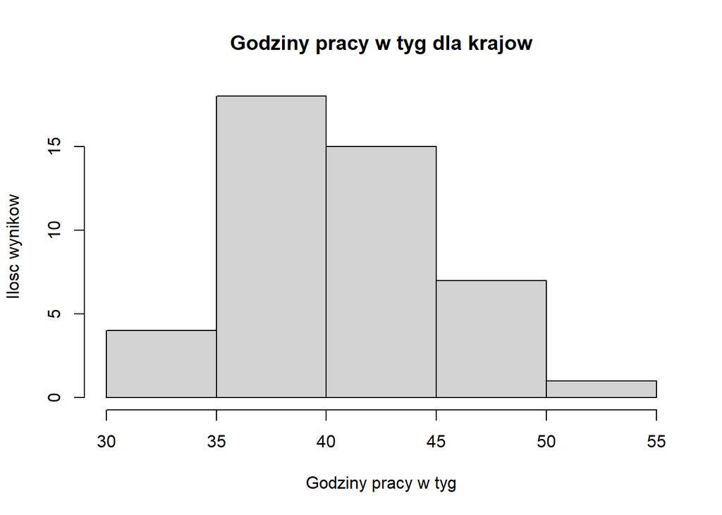

```r
hist(data_no_countries$weekly_hours_worked_15_64, breaks = 4, xlab = "Godziny pracy w tyg", ylab= "Ilosc wynikow",
     main = "Godziny pracy w tyg dla krajow")
```

histogram wizualnie pokazuje mocne skupienie wokół średniej

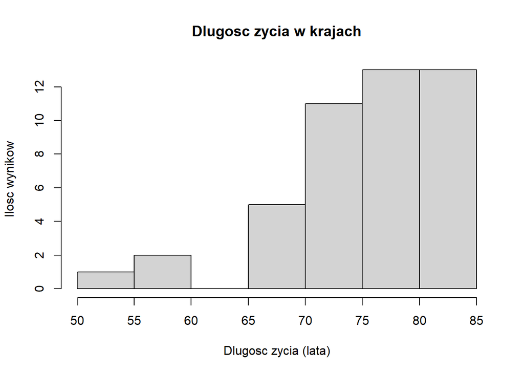

```r
hist(data_no_countries$life_expectancy, breaks = 6, xlab = "Dlugosc zycia (lata)", ylab= "Ilosc wynikow",
     main = "Dlugosc zycia w krajach")
```

Lewostronnie skośna długość życia.

# Korelacja

```r
cor(data_no_countries)
```

```
##                           gdp_per_capita gdp_per_capita_ppp life_expectancy income_inequality enrollment_tetriary weekly_hours_worked_15_64
## gdp_per_capita                 1.0000000          0.9766731       0.6030726        -0.4682286           0.3283179                -0.4164299
## gdp_per_capita_ppp             0.9766731          1.0000000       0.6762764        -0.4893625           0.3998767                -0.3857115
## life_expectancy                0.6030726          0.6762764       1.0000000        -0.4462177           0.6747310                -0.2874810
## income_inequality             -0.4682286         -0.4893625      -0.4462177         1.0000000          -0.4870226                 0.2600362
## enrollment_tetriary            0.3283179          0.3998767       0.6747310        -0.4870226           1.0000000                -0.1974662
## weekly_hours_worked_15_64     -0.4164299         -0.3857115      -0.2874810         0.2600362          -0.1974662                 1.0000000
```

Jako, że analizujemy wpływ na godziny pracy, to najważniejszy jest dla nas ostatni wiersz widać tam, że jedyna pozytywna korelacja jest między nierównością dochodową, a godzinami pracy, im większa nierówność, tym więcej pracują.

Żaden współczynnik nie wskazuje na silna korelację (maksymalnie na umiarkowaną ~-0.4), ale wszystkie pozostałe wskaźniki potwierdzają tezę, że im bardziej rozwinięty kraj:

- (wyższe PKB per capita PPP),
- próba wyższej edukacji (większy enrollment rate może wskazywać także na bardziej opiekuńcze państwo)
- długość życia (aczkolwiek tu wpływ raczej ma praca na długość życia, nie na odwrót)

tym mniejsza ilość godzin pracy w tygodniu. Zgodnie z naszym założeniem.